# Exercícios: Análises Ecológicas no R

2022-02-08

**Exercícios: Análises Ecológicas no R**

Nesta página você encontrará as soluções para os exercícios propostos no livro [Análises Ecológicas no R](https://analises-ecologicas.netlify.app/).

# Capítulo 6 - Visualização de dados

## Exercício 6.1

Utilizando o banco de dados `penguins` compare o comprimento do bico entre as diferentes espécies de penguins. Utilize um gráfico de caixa (boxplot) para ilustrar a variação intraespecífica e possíveis outiers nos dados. Para melhorar o seu gráfico, lembre-se de nomear o os dois eixos corretamente, definir um tema e posicionar a legenda.

### Solução

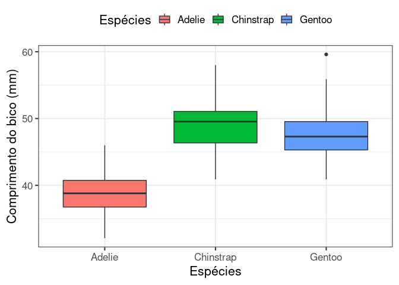

```r
# Carregando pacotes necesários
library(tidyverse)
library(ecodados)

## Dados
penguins <- palmerpenguins::penguins

## Edição dos nomes das colunas para português
# names(penguins)
colnames(penguins) <- c("especies", "ilha", "comprimento_bico",
                        "profundidade_bico", "comprimento_nadadeira",
                        "massa_corporal", "sexo", "ano")

# Gráfico: Boxplot do tamanho do bico entre as diferentes espécies
ggplot(penguins, aes(y = comprimento_bico, x = especies, fill = especies)) +
  geom_boxplot() +
  theme_bw(base_size = 16) +
  theme(
    legend.position = "top"
  ) +
  labs(fill = "Espécies",
       x = "Espécies", y = "Comprimento do bico (mm)")
```

## Exercício 6.2

Utilizando o banco de dados `penguins` faça um [histograma](https://analises-ecologicas.netlify.app/cap6.html#histograma-histogram) com a distribuição da massa corporal para cada uma das espécies. Utilize uma cor de preenchimento para cada espécie.

### Solução

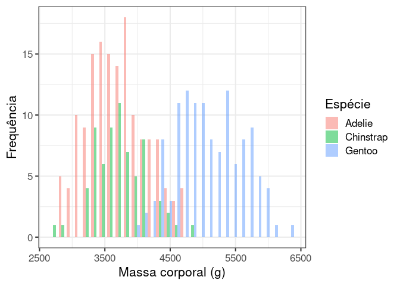

```r
ggplot(penguins, aes(x = massa_corporal, fill = especies)) +
  geom_histogram(alpha = .5,  position = position_dodge()) +
  theme_bw(base_size = 16) +
  labs(x = "Massa corporal (g)",
       y = "Frequência",
       fill = "Espécie")
```

## Exercício 6.3

Utilizando o banco de dados `penguins`, produza três gráficos com o mesmo eixo Y e eixo X. Coloque o comprimento das nadadeiras no eixo Y as espécies de pinguins no eixo X. No primeiro grafico, utilize o `geom_jitter` para plotar os dados brutos. No segundo gráfico, utilize o `geom_violin` para mostrar a distribuição de densidade dos dados. No terceiro gráfico, utilize o `geom_boxplot` para destacar a mediana e os quartis.

### Solução

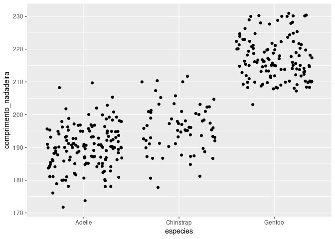

```r
# Gráfico de jitter com dados brutos
pjitter <- ggplot(penguins, aes(y = comprimento_nadadeira, x = especies )) +
  geom_jitter()
pjitter
```

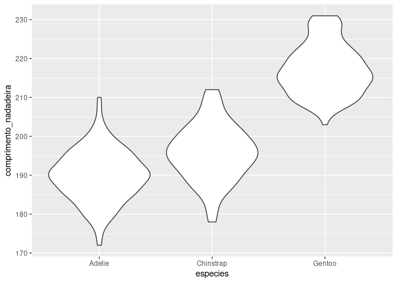

```r
# Gráfico violin com a densidade dos dados
pviolin <- ggplot(penguins, aes(y = comprimento_nadadeira, x = especies )) +
  geom_violin()
pviolin
```

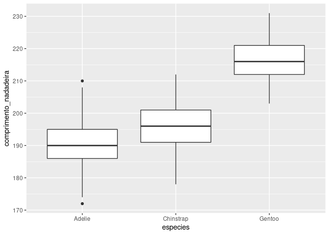

```r
# Gráfico de caixa com a media e os quartis
pcaixa  <- ggplot(penguins, aes(y = comprimento_nadadeira, x = especies )) +
  geom_boxplot()
pcaixa
```

## Exercício 6.4

Se você conseguiu resolver o exercício 6.3, agora dê um passo a mais e compare os três gráficos lado a lado utilizando o comando `grid.arrange`. Lembre-se de colocar um título informativo em cada um dos gráficos antes de juntá-los em uma prancha única. Ao comparar os 3 tipos de gráficos, qual você considera mais informativo? Experimente combinar mais de um “geom” e produzir gráficos ainda mais interessantes.

### Solução

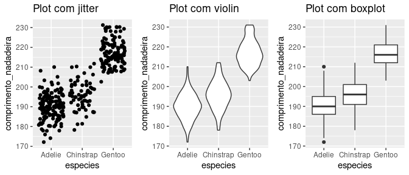

```r
# colocando um título em cada gráfico
pjitter <- pjitter + labs(title = "Plot com jitter")
pviolin <- pviolin + labs(title = "Plot com violin")
pcaixa  <- pcaixa + labs(title = "Plot com boxplot")

# juntando os 3 gráficos em um só
# Carregando o pacote gridExtra
library(gridExtra)
grid.arrange(pjitter, pviolin, pcaixa, ncol = 3)
```

Agora misturando as camadas.

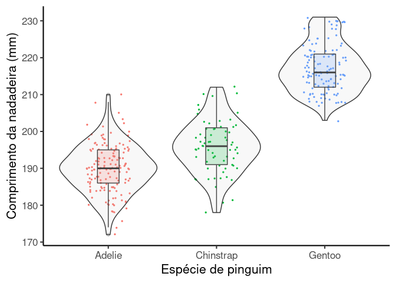

```r
# Misturando geoms
ggplot(penguins, aes(y = comprimento_nadadeira, x = especies )) +
  geom_jitter(size = .5, width = .2, aes(color = especies)) +
  geom_boxplot(aes(fill = especies), alpha = .2, width = .2) +
  geom_violin(fill = "gray", alpha = .1) +
  theme_classic(base_size = 16) +
  theme(legend.position = "none") +
  labs(y = "Comprimento da nadadeira (mm)",
       x = "Espécie de pinguim")
```

## Exercício 6.5

Utilize o banco de dados `ecodados::anova_dois_fatores` para construir um [gráfico de barras](https://analises-ecologicas.netlify.app/cap6.html#gr%C3%A1fico-de-barras-bar-plot) com a média e o erro padrão do Tempo (Tempo para eliminar a droga do corpo) no eixo Y em funçao da variável Pessoas (XX, ou XY) e Idade (jovem ou idoso). Antes de fazer o gráfico leia com a atenção a descrição do mesmo através do comando `?ecodados::anova_dois_fatores`. Um dica, utilize `fill` dentro do `aes` para representar um dos fatores (ex. Pessoas). O outro fator você pode representar no eixo X. Veja se consegue, se não conseguir pode olhar a cola com a solução para aprender como é feito. Outra dica, pesquise sobre a função `stat_summary` ela pode te ajudar a calcular a média e o erro padrão dentro do comando que gera o gráfico.

### Solução

```r
# entenda o banco de dados primeiro
?ecodados::anova_dois_fatores
```

**Versão 1**: calculando a média e o erro padrão dentro do próprio gráfico.

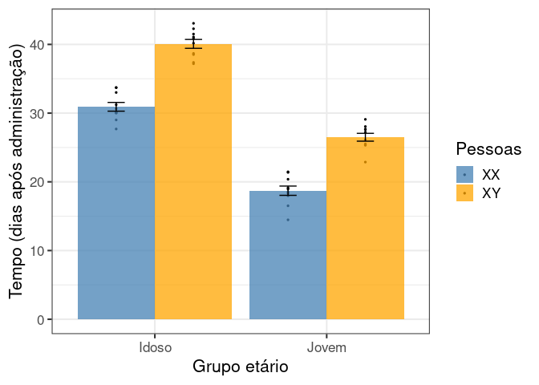

```r
ggplot(anova_dois_fatores, aes(y = Tempo, x = Idade, fill = Pessoas)) +
  geom_point(position = position_dodge(width = .9), size = .5) +
  stat_summary(fun = mean, geom = "bar", position = position_dodge(width = .9), alpha = .75) +
  stat_summary(fun.data = mean_se, geom = "errorbar", position = position_dodge(width = .9),
               width = .2) +
  scale_fill_manual(values = c("steelblue", "orange")) +
  theme_bw(base_size = 16) +
  labs(y = "Tempo (dias após administração)",
       x = "Grupo etário")
```

```r
## Calcular o desvio padrão
anova_media <- anova_dois_fatores %>%
    dplyr::group_by(Idade, Pessoas ) %>%
    dplyr::summarise(media = mean(Tempo, na.rm = TRUE),
                     desvio = sd(Tempo, na.rm = TRUE))
#Veja como ficou
head(anova_media)
```

```
## # A tibble: 4 × 4
## # Groups:   Idade [2]
##   Idade Pessoas media desvio
##   <chr> <chr>   <dbl>  <dbl>
## 1 Idoso XX       30.9   2.01
## 2 Idoso XY       40.1   2.04
## 3 Jovem XX       18.7   2.14
## 4 Jovem XY       26.5   1.80
```

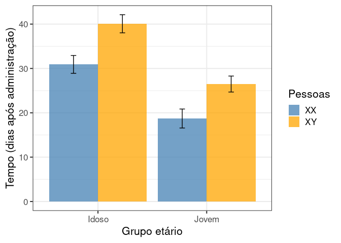

```r
## Gráfico de barras com desvio padrão
ggplot(data = anova_media, aes(y = media, x = Idade, fill = Pessoas)) +
    geom_bar(stat = "identity", alpha = .75, position = position_dodge()) +
    geom_errorbar(aes(ymin = media - desvio, ymax = media + desvio),
                  width = .1, position = position_dodge(width = .9)) +
  scale_fill_manual(values = c("steelblue", "orange")) +
  theme_bw(base_size = 16) +
  labs(y = "Tempo (dias após administração)",
       x = "Grupo etário")
```

## Exercícios 6.6

Utilize o banco de dados `penguins` para criar um [gráfico de dispersão](https://analises-ecologicas.netlify.app/cap6.html#gr%C3%A1fico-de-dispers%C3%A3o-scatter-plot) entre o tamanho da nadadeira (eixo Y) e a massa corporal (eixo X). Utilize o argumento `fill` para ilustrar com cores as diferenças entre os sexos e utilize o comanto `facte_grid()` para criar um gráfico separado para cada espécie de pinguim. Se você não conhece essa função, dê uma olhada no help `?facet_grid`. Você também pode utilizar a função `drop_na()` para excluir os dados faltantes da coluna `sexo`.

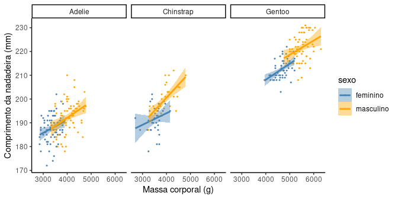

```r
# primeiro vamos traduizir a coluna sexo para o português
penguins$sexo <- fct_recode(penguins$sexo, masculino = "male", feminino = "female")

ggplot(penguins %>% drop_na(sexo), aes(y = comprimento_nadadeira, x = massa_corporal,
                                       color = sexo, fill = sexo)) +
  geom_point(size = .4) +
  geom_smooth(method = lm) +
  facet_grid(~especies) +
  scale_color_manual(values = c("steelblue", "orange"), aesthetics = c("fill", "color")) +
  theme_classic() +
  labs(
    y = "Comprimento da nadadeira (mm)",
    x = "Massa corporal (g)"
  )
```